# Analysis of the Activity Dataset

2023-04-05

## Load the necessary libraries

```r
library(dplyr)
library(ggplot2)
```

## Reading Data

```r
path <- "./data/activity.csv"
df <- read.csv(path)
df$date <- as.Date(df$date)

summary(df)
```

```
##      steps             date               interval
##  Min.   :  0.00   Min.   :2012-10-01   Min.   :   0.0
##  1st Qu.:  0.00   1st Qu.:2012-10-16   1st Qu.: 588.8
##  Median :  0.00   Median :2012-10-31   Median :1177.5
##  Mean   : 37.38   Mean   :2012-10-31   Mean   :1177.5
##  3rd Qu.: 12.00   3rd Qu.:2012-11-15   3rd Qu.:1766.2
##  Max.   :806.00   Max.   :2012-11-30   Max.   :2355.0
##  NA's   :2304
```

## Histogram of the total number of steps taken each day

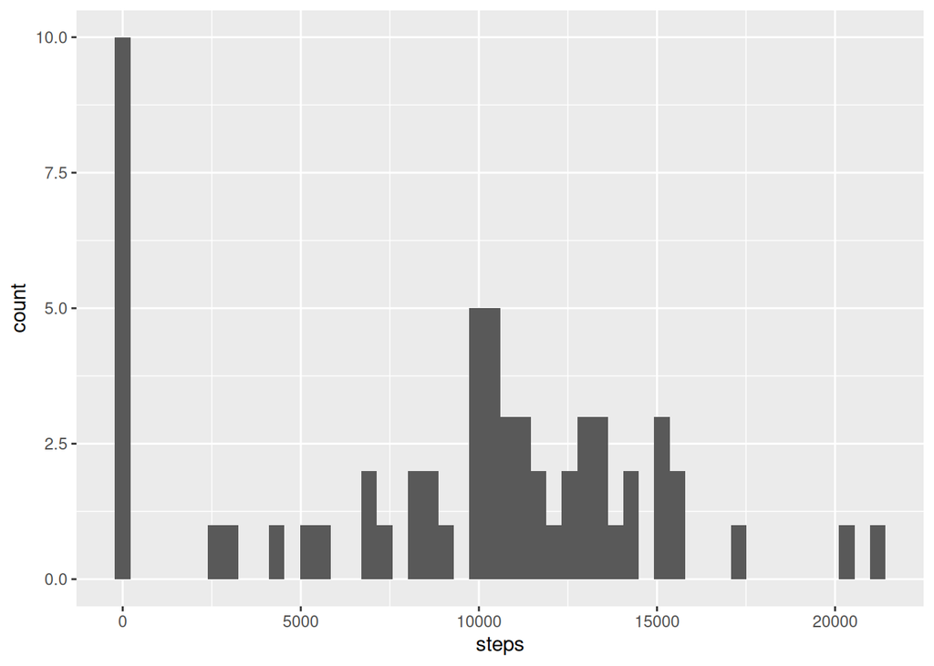

```r
steps_per_day <- df %>% group_by(date) %>% summarise(steps=sum(steps, na.rm = TRUE))
ggplot(steps_per_day, aes(x=steps)) + geom_histogram(bins = 50)
```

## Mean and median number of steps taken each day

```r
df %>%
  group_by(date) %>%
  summarise(
    steps_mean=mean(steps, na.rm = TRUE),
    steps_median=median(steps, na.rm = TRUE)
  )
```

```
## # A tibble: 61 × 3
##    date       steps_mean steps_median
##    <date>          <dbl>        <dbl>
##  1 2012-10-01    NaN               NA
##  2 2012-10-02      0.438            0
##  3 2012-10-03     39.4              0
##  4 2012-10-04     42.1              0
##  5 2012-10-05     46.2              0
##  6 2012-10-06     53.5              0
##  7 2012-10-07     38.2              0
##  8 2012-10-08    NaN               NA
##  9 2012-10-09     44.5              0
## 10 2012-10-10     34.4              0
## # … with 51 more rows
```

Since most of intervals in a given day have 0 steps, the median is pretty much always equal to 0.

## Time series plot of the average number of steps taken

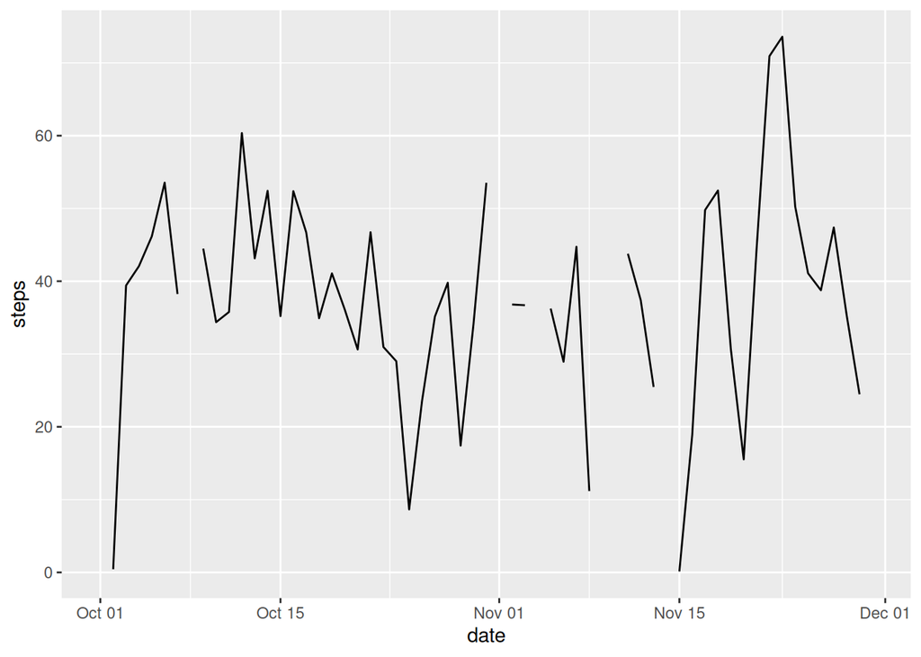

```r
mean_steps <- df %>%
  group_by(date) %>%
  summarise(steps=mean(steps, na.rm = TRUE))

ggplot(mean_steps, aes(x=date, y=steps)) + geom_line()
```

Since we haven’t removed the missing data, the timeseries has some gaps.

## The 5-minute interval that, on average, contains the maximum number of steps

```r
df %>%
  group_by(interval) %>%
  summarise(mean_steps = mean(steps, na.rm = TRUE)) %>%
  arrange(desc(mean_steps)) %>%
  head(n = 1)
```

```
## # A tibble: 1 × 2
##   interval mean_steps
##      <int>      <dbl>
## 1      835       206.
```

The interval 835-840 of minutes on average has the greatest number of steps.

## Code to describe and show a strategy for imputing missing data

```r
df[is.na(df$steps),] %>% group_by(date) %>% summarise(n())
```

```
## # A tibble: 8 × 2
##   date       `n()`
##   <date>     <int>
## 1 2012-10-01   288
## 2 2012-10-08   288
## 3 2012-11-01   288
## 4 2012-11-04   288
## 5 2012-11-09   288
## 6 2012-11-10   288
## 7 2012-11-14   288
## 8 2012-11-30   288
```

Looking at the missing data it seems that we’re always missing the whole days.

Usually one day at a time. There’s one case 09-11-2012 - 10-11-2012 where there are two missing days in a row.

Fill the missing data using the mean value for each of the intervals:

```r
filled_df <- df %>%
  group_by(interval) %>%
  mutate(steps=ifelse(is.na(steps), mean(steps, na.rm = TRUE), steps))
```

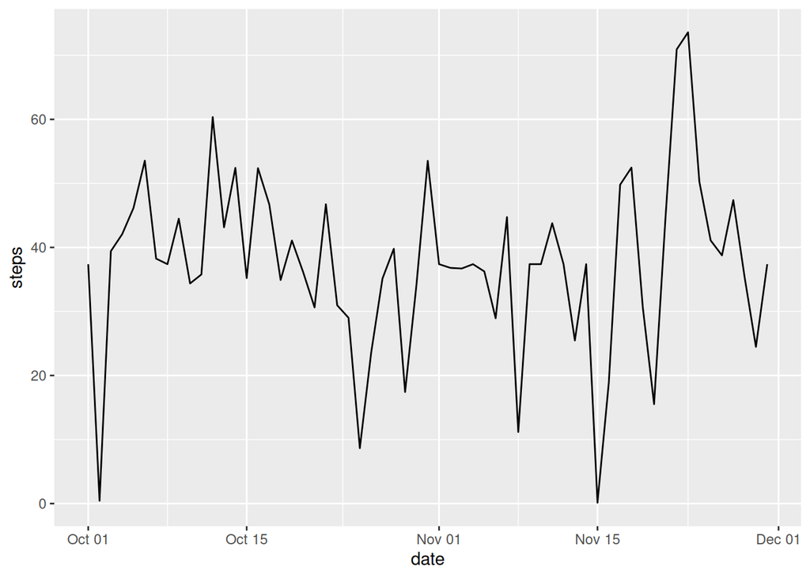

```r
mean_steps <- filled_df %>%
  group_by(date) %>%
  summarise(steps=mean(steps, na.rm = TRUE))

ggplot(mean_steps, aes(x=date, y=steps)) + geom_line()
```

We can see that the new timeseries doesn’t have the gaps that the previous one had.

## Panel plot comparing the average number of steps taken per 5-minute interval across weekdays and weekends

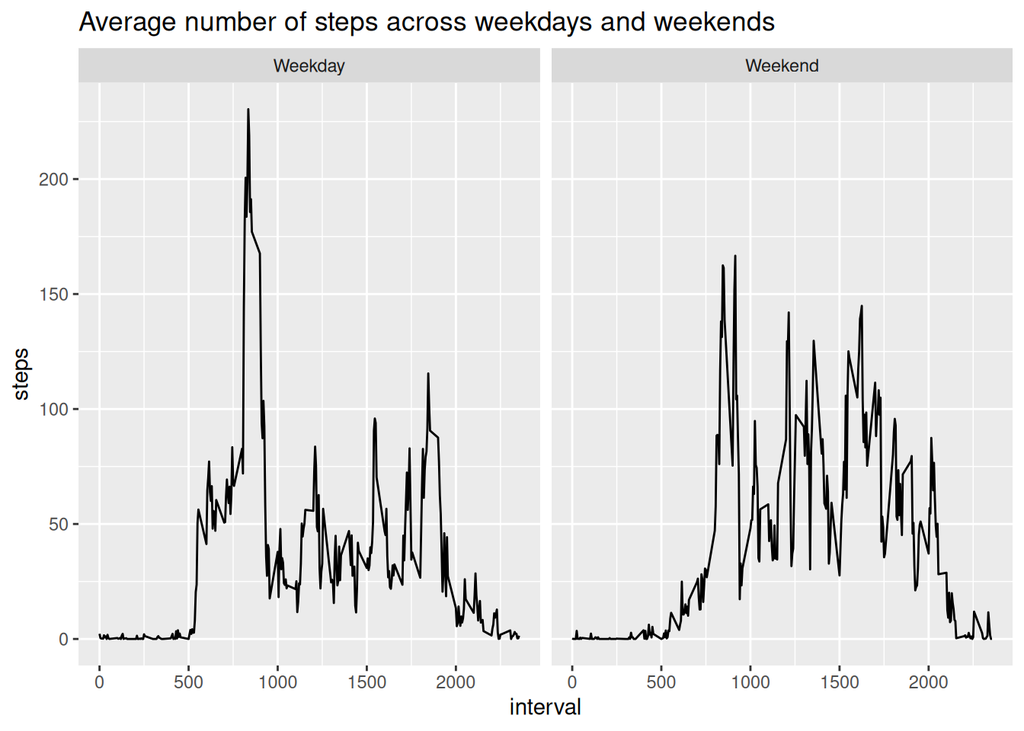

```r
data <- filled_df %>%
  mutate(is_weekend=format(date, "%a") %in% c("Sat", "Sun")) %>%
  group_by(is_weekend, interval) %>%
  summarise(steps=mean(steps, na.rm = TRUE), .groups = "drop")

ggplot(data, aes(x=interval, y=steps)) +
  geom_line() +
  facet_grid(
    . ~ is_weekend,
    labeller = labeller(is_weekend = c("TRUE" = "Weekend", "FALSE" = "Weekday"))) +
  labs(title = "Average number of steps across weekdays and weekends")
```